# WordVector Exploratory for Medical Jurisprudence

Nettles

November 13, 2016

This notebook explores the use of wordVectors for application on the medical jurisprudence files in the MOML database. I am interested the use of racial terminology in these texts and evidence of their distinction in relation to discussions of disease.  
As an initial step, I am going to build a set of racial terms and then look at the similiarities and differences between them.

The lexicon of terms comes from the documents themselves. By iteratively modeling terms “nearest_to” an initial set of labels, I can build a list of words that are used to describe various races. I found that model quickly begins to include religion and geographic locations. For example, “Jew” refers to both race and religion; I inlcuded it in the list because the Jewish are often treated as a race through history. More generic terms, such as “ethnic” are included because they typically refer to people viewed as “other.”

Upon completion of my modeling, I have a list of racial terms and a set of related terms for the entire medical jurisprudence corpus:

```r
some_races = model %>%
  nearest_to(model[[c( "race", "caucasian","races","esquimaux" , "aboriginal" ,"chaldaic" , "ethnic" , "european" , "jews","eskimo" , "australoid", "australians","africans","mongolians","chaco" ,"japanese" , "negroid" , "jews","mohammedans", "asiatics" , "tribes" , "europeans", "hottentots", "mexican", "hebrew" , "malays", "islanders", "chinese", "hindoos","germanic", "greeks", "italians", "asia")]],300) %>% names
#sample(some_races, 30)
```

Next, I want to create models of terms for specific racial groups so that I can compare them against each other and the overall “some_races” model.

It’s encouraging that there are lots of diseases associated with discusssion of “asiatics”, but I’m looking for racial terms. It’s possible that the term is being used to describe diseases (e.g., asiatic flu.) I seeded the model with a couple of specific population groups that I know were present in the US during this period, the Chinese, Japanses, and Filipino, which improved my results.

.

Here’s the final Asian list:

```r
races_asian = nearest_to(model,model[[c( "asiatic" , "chinese", "japanese", "filipino" , "hindoos" , "asia" , "persia" , "islanders" , "sandwich" , "tahiti", "islands", "tribes","indians", "aboriginal")]],300)
```

A plot of the results looks promising.

[output not shown]

[output not shown]

[output not shown]

[output not shown]

[output not shown]

[output not shown]

[output not shown]

[output not shown]

[output not shown]

[output not shown]

[output not shown]

[output not shown]

[output not shown]

[output not shown]

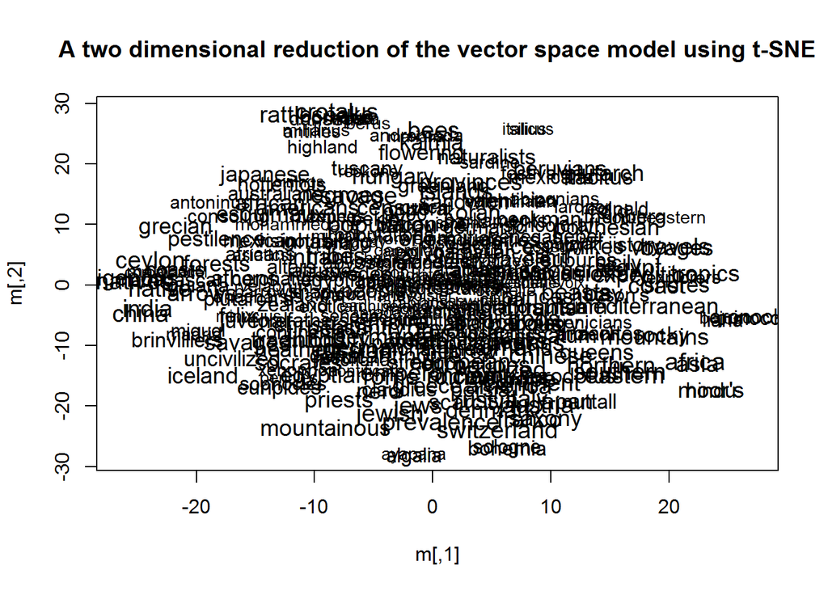

The dendogram suggests no significant subsets.

[figure not shown]

```r
race_asian_distances = cosineDist(races_asian,races_asian) %>% as.dist
plot(as.dendrogram(hclust(race_asian_distances)),horiz=F,cex=1,main="Cluster dendrogram of the fifty words closest to an Asian race vector\nin medical jurisprudence texts from the MOML")
```

Now I’m going to work on African American terminology.

.

.

```r
races_afram = nearest_to(model,model[[c("negro" , "mulatto", "mulattoes" , "negress" , "creole", "african" , "mulattoes" , "spades" , "albino" ,  "mongolians" )]],300)
```

Lastly, Hispanic:

```r
races_hispanic = nearest_to(model,model[[c("mexican", "mexicans", "peruvians", "sardine", "madrid")]],300)
```

Now that I have a series of racial vector sets, I want to try some visualizations. I’ll start with the top 300 words in relation to their similarity to African Americans and Asians. Notice the term “charlevoix” off to the right – we’ll come back to that later.

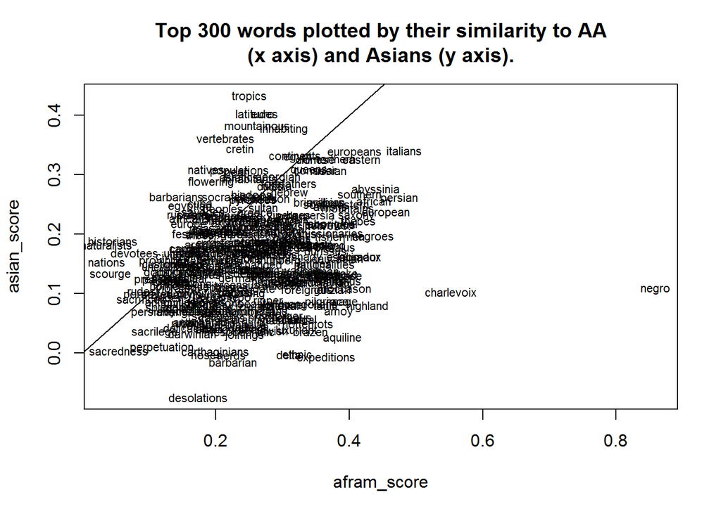

This is a comparison of the four racial groups in terms of their nearness to one another:

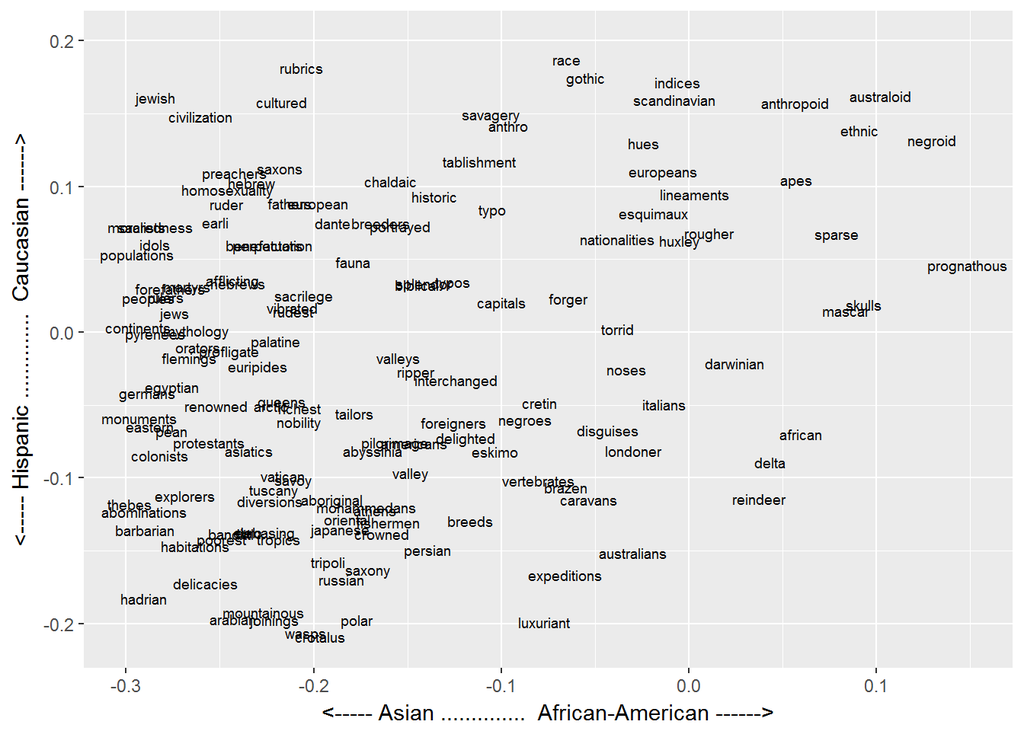

```r
all_races = data.frame(word = rownames(races))

#names(races_afram)

#This stilll isn't working -- it is calling the names, but not the values, resulting in a blank graph. Leaving this alone for now.
#aa_asian_vector = model[[names(races_afram)]] - model[[names(races_asian)]]

aa_asian_vector = model[[c("negro" , "mulatto", "mulattoes" , "negress" , "creole", "african" , "mulattoes" , "spades" , "albino" ,  "mongolians")]] - model[[c( "asiatic" , "chinese", "japanese", "filipino" , "hindoos" , "asia" , "persia" , "islanders" , "sandwich" , "tahiti", "islands", "tribes","indians", "aboriginal")]]


all_races$aa_vs_asian = cosineSimilarity(races,aa_asian_vector)

white_hispanic_vector = model[[c("caucasian", "aryan", "anglo", "saxon","hispanic", "english")]] - model[[c("mexican", "mexicans", "peruvians", "sardine", "madrid")]]

all_races$white_vs_hispanic = cosineSimilarity(races,white_hispanic_vector)

library(ggplot2)
ggplot(all_races,aes(x=aa_vs_asian,y=white_vs_hispanic,label=word)) + geom_text(size=2.5) +
  scale_y_continuous("<----- Hispanic ..............  Caucasian ------>",limits=c(-.21,.2)) +
  scale_x_continuous("<----- Asian ..............  African-American ------>",limits=c(-.30,.15))
```

Looking over the races vector:

[output not shown]

[output not shown]

[output not shown]

[output not shown]

[output not shown]

[output not shown]

[output not shown]

[output not shown]

[output not shown]

[output not shown]

[output not shown]

[output not shown]

[output not shown]

[output not shown]

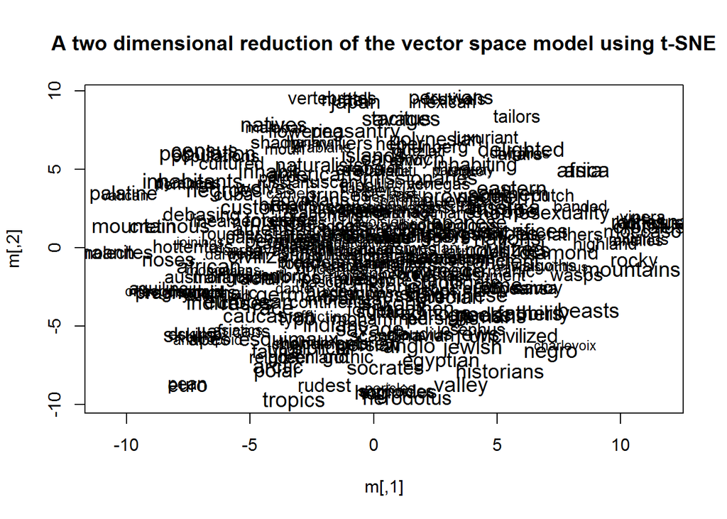

```r
plot(races, perplexity=50)
```

“charlevoix” is a term that has come up in previous modeling. I found a reference for a Jesuit priest, Father Pierre François Xavier de Charlevoix, who is considered the first historian of New France. I also found his observations quoted in a text discussing the negro race.

```r
races %>% nearest_to(races[[c("charlevoix")]],50) %>% names
```

```
##  [1] "charlevoix"     "labrador"       "amoy"           "bojesmans"
##  [5] "missionaries"   "persia"         "paraguay"       "bashaw"
##  [9] "tahiti"         "bossu"          "chaco"          "hottentots"
## [13] "migratory"      "peruvians"      "islanders"      "gutzlaff"
## [17] "festivals"      "venegas"        "norwegian"      "tacitus"
## [21] "persian"        "arabs"          "chindaswinthus" "sparman"
## [25] "carthagenians"  "thebes"         "thunberg"       "claudius"
## [29] "disgraces"      "colonists"      "molech"         "mountains"
## [33] "brazen"         "canaanites"     "arabian"        "chinese"
## [37] "savages"        "sandwich"       "greenland"      "consular"
## [41] "poorest"        "herodotus"      "mexican"        "altars"
## [45] "luxuriant"      "negro"          "persians"       "barbarian"
## [49] "japanese"       "profligate"
```

What happens if I remove words associated with Charlevoix from words associated with negro?

```r
races %>% nearest_to(races[["negro"]] - races[["charlevoix"]])
```

```
##         negro       negroid orthognathous    australoid      aquiline
##     0.5148716     0.7322003     0.7567322     0.7625493     0.7772768
##   prognathous         races        skulls  mesocephalic     esquimaux
##     0.7826688     0.7851648     0.7943256     0.7993371     0.8027715
```

The results become more oriented toward the language of biological anthopology and possibly eugenics. If I look for words associated with Francis Galton (who was a primary proponent of eugentics), I get this set of terms.

```r
races %>% nearest_to(races[[c("galton")]],50) %>% names
```

```
##  [1] "countries"    "ancient"      "america"      "race"
##  [5] "europe"       "nations"      "negro"        "population"
##  [9] "civilized"    "european"     "inhabitants"  "savage"
## [13] "rome"         "southern"     "races"        "civilization"
## [17] "indians"      "islands"      "eastern"      "northern"
## [21] "negroes"      "customs"      "arctic"       "jews"
## [25] "natives"      "fathers"      "romans"       "chinese"
## [29] "provinces"    "egypt"        "africa"       "jewish"
## [33] "russia"       "skulls"       "tribes"       "germans"
## [37] "russian"      "anglo"        "beasts"       "gods"
## [41] "savages"      "saxony"       "mountains"    "asia"
## [45] "african"      "delighted"    "sacrifices"   "greeks"
## [49] "greece"       "valley"
```

Subtracting both Galton and Charveloix associated terms from the negro vector:

```r
races %>% nearest_to(races[["negro"]] - races[["charlevoix"]] - races[["galton"]])
```

```
##  countries    ancient    america       race     europe    nations
##        NaN        NaN        NaN        NaN        NaN        NaN
##      negro population  civilized   european
##        NaN        NaN        NaN        NaN
```

Lookin forward, I need to make sure I’ve got a good set of racial terms and then make sure they’re all included in the all_races vector. There are a lot of different directions I could take this; for now, the plan is test the finished model against other corpus subsets to see if it works across subject areas. Another area of investigation is to create public health vectors and assess their relationship with race vectors.